# Vignette - DipserseR

In this vignette you will see how to use the `disperseR` package. We will walk you through an example step by step. In this vignette we are using functions that will automatically download the needed data for you to be able to run an analysis for the United States. We also provide other vignettes that show you how we processed the data (optional).

## The step up

We start by importing the packages that we will use in the analysis. Make sure you have them installed. The functions in `disperseR` are based on the `data.table` package for faster computation, but this vignette contains many functions from the `tidyverse` family to illustrate another syntax.

```r
library(disperseR) # our package
library(ncdf4)
library(data.table)
library(tidyverse)
library(parallel)
library(sf)
library(viridis)
library(ggplot2)
library(scales)
library(ggsn)
library(gridExtra)
library(ggmap)
library(ggrepel)
```

Next, we will use the `create_dirs()` function that creates a project folder with all the necessary sub folders. We recommend that you begin by setting up your project with this function. Provide the path to where you would like your project to live in the `location` argument. By default, if you do not specify the path, this function will create a main directory on your desktop. It will also assign paths to string variables in your environment.

This will set up is the following folders and paths to them :

- `main`: the main folder where the project will be located.
- `input`: the input that we need for calculations.
  - `zcta_500k`: ZCTA (A Zip Code Tabulation Area) shape files
  - `hpbl`: monthly global planetary boundary layer files.
  - `meteo`: (reanalysis) meteorology files
- `output`
  - `hysplit`: disperseR output (one file for each emissions event)
  - `ziplink`: files containing ZIP code linkages
  - `rdata`: RData files containing HyADS source-receptor matrices
  - `exp`: exposure per zipcode data
  - `graph`: graphs saved here as pdf when running functions
- `process`: temporary files that are created when the model is running and then deleted

Note that not specifying the `location` argument will lead to a default Desktop location for the project folder. You can specify another folder by typing: `disperseR::create_dirs(location="/Users/username/projectlocation")` instead.

```r
disperseR::create_dirs()
```

```
#> Creating project setup
#> Project created in :  ~/Desktop
```

## The inputs

The next step is to get the data necessary for the analysis. Let’s start by loading data sets that are provided inside the `disperseR` package.

### The crosswalk

ZIP code linkage procedure requires a ZCTA-to-ZIP code crosswalk file. ZCTAs are not exact geographic matches to ZIP codes, and multiple groups compile and maintain Crosswalk files. We used the Crosswalk maintained by UDS Mapper and prepossessed it also including information about the population size. While not necessary for the HYSPLIT model or processing of its outputs, population-weighted exposure metrics allow for direct comparisons between power plants. If you would like to know more details about how this crosswalk was prepared, we have attached a vignette that explains it.

Let’s load the crosswalk file and assign it to `crosswalk`

```r
crosswalk <- disperseR::crosswalk
```

Let’s see the first rows of the dataset.

```r
head(crosswalk)
```

```
#>      ZIP       CITY  ZCTA STATE TOTALESTIMATE MARGINOFERROR
#> 1: 00501 Holtsville 11742    NY         13158           801
#> 2: 00544 Holtsville 11742    NY         13158           801
#> 3: 00601   Adjuntas 00601    PR         17599           261
#> 4: 00602     Aguada 00602    PR         39209           128
#> 5: 00603  Aguadilla 00603    PR         50135           805
#> 6: 00604  Aguadilla 00603    PR         50135           805
```

### The monthly powerplant emissions

The `disperseR` package also includes monthly power plant emissions, load, and heat input data, accessible using the following command:

```r
PP.units.monthly1995_2017 <- disperseR::PP.units.monthly1995_2017
```

Let’s see the first rows of the dataset.

```r
head(PP.units.monthly1995_2017)
```

```
#>    FacID Unit.ID Latitude Longitude year month SO2.tons NOx.tons
#> 1:     3       1  31.0069  -88.0103 1997     1  549.668  182.981
#> 2:     3       1  31.0069  -88.0103 1997     2  518.031  164.897
#> 3:     3       1  31.0069  -88.0103 1997     3  541.160  198.754
#> 4:     3       1  31.0069  -88.0103 1997     4  625.633  229.144
#> 5:     3       1  31.0069  -88.0103 1997     5  646.820  214.673
#> 6:     3       1  31.0069  -88.0103 1997     6  596.652  204.693
#>    HeatIn.MMBtu GrossLoad.MWh uID
#> 1:     781356.4         88691 3.1
#> 2:     748454.5         88023 3.1
#> 3:     749287.1         92233 3.1
#> 4:     906910.5        100555 3.1
#> 5:     890811.5         93559 3.1
#> 6:     853542.6         89507 3.1
```

### ZIP code coordinates

The `disperseR` package contains a data set with coordinates of ZIP codes. This might be useful for plotting, but it is not necessary as it will be used automatically by our plotting functions where required. We are using data from: [Open Data Soft](https://public.opendatasoft.com/explore/dataset/us-zip-code-latitude-and-longitude/table/) If needed however, you can access it as follows:

```r
zipcodecoordinate <- disperseR::zipcodecoordinate
```

Let’s see the first rows of the dataset.

```r
head(zipcodecoordinate)
```

```
#>     ZIP       City Latitude  Longitude
#> 1 67553 Liebenthal 38.65495  -99.32062
#> 2 85743     Tucson 32.33512 -111.14888
#> 3 75016     Irving 32.76727  -96.77763
#> 4 60401    Beecher 41.35048  -87.62408
#> 5 80432       Como 39.24344 -105.79431
#> 6 66081 Wolf River 39.77314  -95.23382
```

### The shape files

Equally important is the ZCTA shape file. Using the `get_data()` function and setting `data = "zctashapefile"` you can download and preprocess the file from the [US census website](http://www2.census.gov/geo/tiger/GENZ2017/shp/cb_2017_us_zcta510_500k.zip) automatically. If the file already exists in the correct folder, this function will preprocess it and load it into your R environment. We have also attached a vignette explaining this preprocessing in detail.

```r
zcta <- disperseR::get_data(data = "zctashapefile")
```

```
#> File already exist, not downloading.
#> Starting Preprocessing
#> Preprocessing complete
```

```r
zcta
```

```
#> class       : SpatialPolygonsDataFrame
#> features    : 33144
#> extent      : -10142462, 3310068, -2072901, 4407201  (xmin, xmax, ymin, ymax)
#> crs         : +proj=aea +lat_1=20 +lat_2=60 +lat_0=40 +lon_0=-96 +x_0=0 +y_0=0 +ellps=GRS80 +datum=NAD83 +units=m +towgs84=0,0,0
#> variables   : 5
#> names       : ZCTA5CE10,     AFFGEOID10, GEOID10,   ALAND10, AWATER10
#> min values  :     00601, 8600000US00601,   00601, 100004777,        0
#> max values  :     99929, 8600000US99929,   99929,  99999601,   999991
```

### Monthly mean planetary boundary layer heights

Another input that we need are the monthly mean boundary layer heights. We used the data available on the [ESRL website](https://www.esrl.noaa.gov/psd/repository/entry/get/hpbl.mon.mean.nc?entryid=synth%3Ae570c8f9-ec09-4e89-93b4-babd5651e7a9%3AL05BUlIvTW9udGhsaWVzL21vbm9sZXZlbC9ocGJsLm1vbi5tZWFuLm5j). Again, using the `get_data()` function and setting `data = "pblheight"`. If you need more information about how these data have been preprocessed just check the special vignette that is available with the package.

```r
pblheight <- disperseR::get_data(data = "pblheight")
```

```
#> File already exist, not downloading.
#> Preprocessing complete
```

```r
pblheight
```

```
#> class      : RasterBrick
#> dimensions : 277, 349, 96673, 487  (nrow, ncol, ncell, nlayers)
#> resolution : 32462.99, 32463  (x, y)
#> extent     : -16231.49, 11313351, -16231.5, 8976020  (xmin, xmax, ymin, ymax)
#> crs        : +proj=lcc +x_0=5632642.22547 +y_0=4612545.65137 +lat_0=50 +lon_0=-107 +lat_1=50 +ellps=WGS84 +lat_2=45
#> source     : /Users/majagarbulinska/Desktop/main/input/hpbl/hpbl.mon.mean.nc
#> names      : X1979.01.01, X1979.02.01, X1979.03.01, X1979.04.01, X1979.05.01, X1979.06.01, X1979.07.01, X1979.08.01, X1979.09.01, X1979.10.01, X1979.11.01, X1979.12.01, X1980.01.01, X1980.02.01, X1980.03.01, ...
#> Date/time  : 1979-01-01, 2019-07-01 (min, max)
#> varname    : hpbl
```

### The units data

This package contains annual emissions and stack height data from [EPA’s Air Markets Program Data](https://ampd.epa.gov/ampd/) and the [Energy Information Agency](https://www.eia.gov/electricity/data/eia860/) for years 2003-2012. Again, if you would like to know how these data were prepared please see the special vignette that we have attached to this package.

```r
unitsrun2005 <- disperseR::units %>%
  dplyr::filter(year ==2005)%>%
  dplyr::top_n(2, SOx)

unitsrun2006 <- disperseR::units %>%
  dplyr::filter(year ==2006)%>%
  dplyr::top_n(2, SOx)

head(unitsrun2005)
```

```
#>       ID Latitude Longitude      SOx      CO2      NOx   Height     Diam
#> 1 3136-1  40.6604  -79.3411 183555.8 13322458 13787.34 171.6024 10.36320
#> 2 3149-1  41.0714  -76.6672 240250.9 18188647 22388.27 213.3600  9.38784
#>   Velocity     Temp inputed year    uID
#> 1  38.7096 283.6983       0 2005 3136.1
#> 2  39.6240 285.7033       0 2005 3149.1
```

```r
head(unitsrun2006)
```

```
#>       ID Latitude Longitude      SOx     CO2      NOx   Height    Diam
#> 1 3136-1  40.6604  -79.3411 77544.22 5789319 5434.327 171.6024 10.3632
#> 2 3136-2  40.6604  -79.3411 86809.31 6481797 7349.269 171.6024 10.3632
#>   Velocity     Temp inputed year    uID
#> 1  38.7096 283.6983       0 2006 3136.1
#> 2  38.7096 283.6983       0 2006 3136.2
```

Below append the two datasets together and transform it to `data.table` format.

```r
unitsrun <- data.table::data.table(rbind(unitsrun2005, unitsrun2006))
```

Let’s look at the data.

```r
unitsrun
```

```
#>        ID Latitude Longitude       SOx      CO2       NOx   Height
#> 1: 3136-1  40.6604  -79.3411 183555.84 13322458 13787.340 171.6024
#> 2: 3149-1  41.0714  -76.6672 240250.87 18188647 22388.272 213.3600
#> 3: 3136-1  40.6604  -79.3411  77544.22  5789319  5434.327 171.6024
#> 4: 3136-2  40.6604  -79.3411  86809.31  6481797  7349.269 171.6024
#>        Diam Velocity     Temp inputed year    uID
#> 1: 10.36320  38.7096 283.6983       0 2005 3136.1
#> 2:  9.38784  39.6240 285.7033       0 2005 3149.1
#> 3: 10.36320  38.7096 283.6983       0 2006 3136.1
#> 4: 10.36320  38.7096 283.6983       0 2006 3136.2
```

### The meteorology files

Download reanalysis meteorology files. Below we show code to test for the meteorology files needed for the present run. They will be downloaded if they are not already in the `meteo_dir` folder. The reanalysis met files are about 120 MB each.

```r
disperseR::get_data(data = "metfiles",
  start.year = "2005",
  start.month = "07",
  end.year="2006",
  end.month="06")
```

```
#> No files to download. Requested files already available
```

Now the data should be downloaded to your `meteo_dir` directory and we can start the analysis.

## Analysis

### Define time periods to be run

HYSPLIT, as applied here, tracks air parcels emitted at certain times and locations. `disperseR` refers to these as *emissions events*. Once HYSPLIT has been run for each emissions event, the simulated parcel locations are aggregated by source, time, and location. The functions below are written to enable runs of many emissions events.

```r
input_refs <- define_inputs(units = unitsrun,
  startday = '2005-07-01',
  endday = '2006-06-30',
  start.hours =  c(0, 6, 12, 18),
  duration = 240)

head(input_refs)
```

```
#>        ID year start_hour  start_day duration_emiss_hours
#> 1: 3136-1 2005          0 2005-07-01                    1
#> 2: 3136-1 2005          6 2005-07-01                    1
#> 3: 3136-1 2005         12 2005-07-01                    1
#> 4: 3136-1 2005         18 2005-07-01                    1
#> 5: 3136-1 2005          0 2005-07-02                    1
#> 6: 3136-1 2005          6 2005-07-02                    1
#>    duration_run_hours Latitude Longitude      SOx      CO2      NOx
#> 1:                240  40.6604  -79.3411 183555.8 13322458 13787.34
#> 2:                240  40.6604  -79.3411 183555.8 13322458 13787.34
#> 3:                240  40.6604  -79.3411 183555.8 13322458 13787.34
#> 4:                240  40.6604  -79.3411 183555.8 13322458 13787.34
#> 5:                240  40.6604  -79.3411 183555.8 13322458 13787.34
#> 6:                240  40.6604  -79.3411 183555.8 13322458 13787.34
#>      Height    Diam Velocity     Temp inputed    uID
#> 1: 171.6024 10.3632  38.7096 283.6983       0 3136.1
#> 2: 171.6024 10.3632  38.7096 283.6983       0 3136.1
#> 3: 171.6024 10.3632  38.7096 283.6983       0 3136.1
#> 4: 171.6024 10.3632  38.7096 283.6983       0 3136.1
#> 5: 171.6024 10.3632  38.7096 283.6983       0 3136.1
#> 6: 171.6024 10.3632  38.7096 283.6983       0 3136.1
```

### Run HYSPLIT

The following examples show how to run a small subset (chosen to provide workable examples on a laptop) of emissions events, link to ZIP codes, and plot the results.

The `run_fac_parallel()` function runs HYSPLIT for each emissions event. Inputs defined above, including the projected ZCTA shape file (`zcta`), the ZIP-ZCTA crosswalk (`crosswalk`), the planetary boundary layer raster (`pblheight`), are necessary in the function call. With `link2zip = T` you can link dispersion patterns from individual emissions events to ZIP codes; this, however, somewhat violates the spirit of HyADS, since the large number of emissions events is used as a check on some other uncertainties introduced by the simplifying assumptions.

**If you get an error running HYSPLIT, it is likely because the meteorology files did not download correctly. Check your `meteo_dir` to ensure all files are present and at least 100MB in size.**

Below we subset the data to run the process on a local computer. We only choose the first day and first hour of each month for each of the units that we chose.

```r
input_refs_subset <- input_refs[
  format(as.Date(input_refs$start_day,
  format = "%Y-%m-%d"),
  format = "%d") == "01" & start_hour==0]
```

Now we need to get indexes of the correct rows. In this case will be all the indexes in this subset of data.

```r
run_sample <- seq(1, nrow(input_refs_subset))
```

Let’s see the indexes. Here we will be running the model using all the rows of the `input_refs_subset` data subset.

```r
run_sample
```

```
#>  [1]  1  2  3  4  5  6  7  8  9 10 11 12 13 14 15 16 17 18 19 20 21 22 23
#> [24] 24 25 26 27 28 29 30 31 32 33 34 35 36 37 38 39 40 41 42 43 44 45 46
#> [47] 47 48
```

Now we will run the fac model in parallel. The argument `sample` should take the vector of indexes that we created above, so here it will be the `sample = run_sample` vector.

`input.refs` should be the data table that is the result of the `define_input()` function. Remember that here we are running the model just on a subset.

The `ztca.`, `crosswalk.`, and `pbl.height` arguments are `NULL` by default but you should provide them for the function to run properly. We use the `zcta`, `crosswalk`, and `pblheight` data respectively.

The package has the possibility to use two types of species. The default one is `species = 'so2'`, but you can also use particulate sulfate `species = 'so4p'`.

The `parallel::detectCores()` function automatically detects the number of cores on your machine. If you would like to change on how many cores the model should be run please specify the number of cores. Here, for example we specified the number of cores to be the number of the cores on the machine. If you would like to run this model sequentially please set `mc.cores = 1`.

It is possible that running the below code with output a warning “WARNING: map background file not found ../graphics/arlmap”. It is safe to ignore it.

```r
hysp_raw <- run_fac_parallel(sample = run_sample,
  input.refs = input_refs_subset,
  pbl.height = pblheight,
  crosswalk.= crosswalk,
  zcta. = zcta,
  species = 'so2',
  link2zip = FALSE, ## FALSE BY DEFAULT
  proc_dir = proc_dir,
  overwrite = FALSE, ## FALSE BY DEFAULT
  npart = 100,
  mc.cores = parallel::detectCores())
```

### Link results to ZIP codes

Most current implementations of HyADS, instead of linking dispersion patterns from individual emissions events, link the patterns by month. With the `link_all_units_zip()` function, users can link all air parcels to ZIP codes by month for specified units. Here, we define the variables `yearmons` with combinations of years and months. `link_all_units_zip()` uses another function called `disperser_link_zip()` that runs in the background and reads in all the relevant files (i.e., those that correspond to the provided units) produced by the `run_fac_parallel()` function and saves them. Then it links them to ZIP codes. `link_all_units_zip()` can be set to paralelize the runs by splitting different months on different cores, but you can make it serial just by setting the `mc.cores = 1`. The result of `dipserser_link_zip()` is a data.table of ZIP codes and relative contributions `N`, and an identical `.csv` file is saved to the folder with a path specified by the `ziplink_dir` variable. `N` is not weighted by the `unit`’s emissions.

```r
yearmons<- c(paste0(2005, 7:12),  paste0(2006, 1:6))
```

Let’s look again at our `unitsrun` data set.

```r
unitsrun
```

```
#>        ID Latitude Longitude       SOx      CO2       NOx   Height
#> 1: 3136-1  40.6604  -79.3411 183555.84 13322458 13787.340 171.6024
#> 2: 3149-1  41.0714  -76.6672 240250.87 18188647 22388.272 213.3600
#> 3: 3136-1  40.6604  -79.3411  77544.22  5789319  5434.327 171.6024
#> 4: 3136-2  40.6604  -79.3411  86809.31  6481797  7349.269 171.6024
#>        Diam Velocity     Temp inputed year    uID
#> 1: 10.36320  38.7096 283.6983       0 2005 3136.1
#> 2:  9.38784  39.6240 285.7033       0 2005 3149.1
#> 3: 10.36320  38.7096 283.6983       0 2006 3136.1
#> 4: 10.36320  38.7096 283.6983       0 2006 3136.2
```

We only have three units in our `unitsrun` data set. “3136-1”, “3136-2” and “3149-1”. We will run `link_all_units_zip()` for all of them.

The function will return only the values for units and months that could have been linked to one another.

If you wanted to run `link_all_units_zip()` just for “3149-1” for example, run the code that we commented out below.

```r
#unitsrun<-unitsrun[ID=="3149-1"]
```

```r
data_linked <- link_all_units_zip(units.run=unitsrun,
  mc.cores = 4,
  year.mons = yearmons,
  pbl.height = pblheight,
  crosswalk. = crosswalk,
  duration.run.hours = 240,
  overwrite = FALSE)

head(data_linked)
```

```
#>    seq_len   ZIP           N month unitID                        comb
#> 1:       1 01001 0.001336020 20057 3136-1 month: 20057 unitID :3136-1
#> 2:       1 01002 0.007861813 20057 3136-1 month: 20057 unitID :3136-1
#> 3:       1 01004 0.007861813 20057 3136-1 month: 20057 unitID :3136-1
#> 4:       1 01059 0.007861813 20057 3136-1 month: 20057 unitID :3136-1
#> 5:       1 01003 0.009139589 20057 3136-1 month: 20057 unitID :3136-1
#> 6:       1 01005 0.010097805 20057 3136-1 month: 20057 unitID :3136-1
```

It could be the case that data could not have been linked for a specific month and unit. Below we show how to take a look at the combinations of units and months that were successfully linked.

We can easily do it in the following way:

```r
unique(data_linked$comb)
```

```
#>  [1] "month: 20057 unitID :3136-1"  "month: 20058 unitID :3136-1"
#>  [3] "month: 20059 unitID :3136-1"  "month: 200510 unitID :3136-1"
#>  [5] "month: 200511 unitID :3136-1" "month: 200512 unitID :3136-1"
#>  [7] "month: 20061 unitID :3136-1"  "month: 20062 unitID :3136-1"
#>  [9] "month: 20063 unitID :3136-1"  "month: 20064 unitID :3136-1"
#> [11] "month: 20065 unitID :3136-1"  "month: 20066 unitID :3136-1"
#> [13] "month: 20057 unitID :3149-1"  "month: 20058 unitID :3149-1"
#> [15] "month: 20059 unitID :3149-1"  "month: 200510 unitID :3149-1"
#> [17] "month: 200511 unitID :3149-1" "month: 200512 unitID :3149-1"
#> [19] "month: 20061 unitID :3149-1"  "month: 20062 unitID :3149-1"
#> [21] "month: 20063 unitID :3149-1"  "month: 20064 unitID :3149-1"
#> [23] "month: 20065 unitID :3149-1"  "month: 20066 unitID :3149-1"
#> [25] "month: 20057 unitID :3136-2"  "month: 20058 unitID :3136-2"
#> [27] "month: 20059 unitID :3136-2"  "month: 200510 unitID :3136-2"
#> [29] "month: 200511 unitID :3136-2" "month: 200512 unitID :3136-2"
#> [31] "month: 20061 unitID :3136-2"  "month: 20062 unitID :3136-2"
#> [33] "month: 20063 unitID :3136-2"  "month: 20064 unitID :3136-2"
#> [35] "month: 20065 unitID :3136-2"  "month: 20066 unitID :3136-2"
```

### Visualization of the results.

At this point, it makes sense to take a look at the results to see which ZIP codes are impacted by emissions from the facility whose impacts we modeled above. We can see how the impact looks by looking at numbers and plots. We will first just look at the numbers. For this purpose, we created a function `create_impact_table_single` that generates a specific data.table.

First we need to bring in the zcta data set as follows.

```r
zcta_dataset <- disperseR::get_data("zcta_dataset")
```

```
#> File already exist, not downloading.
#> Starting Preprocessing
```

And now we can use the `create_impact_table_single` function to see the computed impact for a single month and a single unit.

Keep in mind, since we only modeled a subset of the potential model runs defined in `input_refs`, the impacts contained in `impact_table_single` and plotted below include only results from a single emissions event (is it actually a single event of single month?). Further, the plotted values are “HyADS raw exposure”, and are comparable only to a relative exposure of 0. So, a value of 0.01 represents 10x more exposure than a value of 0.001, but only in relation to unit 3136-1.

```r
impact_table_single <- create_impact_table_single(data.linked=data_linked,
  data.units = unitsrun,
  zcta.dataset = zcta_dataset,
  map.unitID = "3136-1",
  map.month = "20058",
  metric = 'N')

head(impact_table_single)
```

```
#>    unitID Latitude Longitude     metric   ZIP  ZCTA    PO_NAME STATE
#> 1: 3136-1  40.6604  -79.3411 0.00646815 00501 11742 Holtsville    NY
#> 2: 3136-1  40.6604  -79.3411 0.00646815 00501 11742 Holtsville    NY
#> 3: 3136-1  40.6604  -79.3411 0.00646815 00544 11742 Holtsville    NY
#> 4: 3136-1  40.6604  -79.3411 0.00646815 00544 11742 Holtsville    NY
#> 5: 3136-1  40.6604  -79.3411 0.00138947 01005 01005      Barre    MA
#> 6: 3136-1  40.6604  -79.3411 0.00138947 01005 01005      Barre    MA
#>    TOTALESTIMATE MARGINOFERROR
#> 1:         13158           801
#> 2:         13158           801
#> 3:         13158           801
#> 4:         13158           801
#> 5:          5014           269
#> 6:          5014           269
```

In a similar way we can just plot the results using the `plot_impact_single` function. A customized title can be set using the `plot.title` argument.

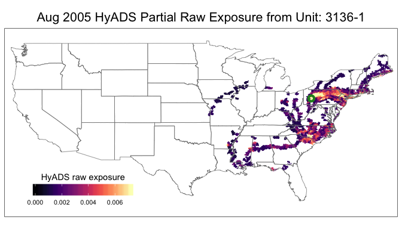

```r
ziplink_plot <- plot_impact_single(data.linked=data_linked,
  map.unitID = "3136-1",
  map.month = "20058",
  data.units = unitsrun,
  zcta.dataset = zcta_dataset,
  metric = 'N',
  graph.dir = graph_dir,
  legend.title = 'HyADS raw exposure')

ziplink_plot
```

### Combine all results into RData file.

So far, we have run two worker functions important to the implementation of HyADS:

`run_fac_parallel()` ran HYSPLIT for unit-date-time emission event combinations and saved an output file for each gathered output files from `run_fac_parallel()`. Then the `link_all_units_zip()` function grouped them by month and unit, and linked the HYSPLIT parcel locations contained in the files to ZIP codes. In practice, these two worker functions may need to be implemented in parallel R sessions on a cluster to improve efficiency. It helps for future analyses to gather the relevant monthly files and save them as a single RData file. This is made possible by `combine_monthly_ziplinks()`, which saves an RData file of annual monthly results to the `rda_dir`.

```r
combined_ziplinks <- combine_monthly_ziplinks(month_YYYYMMs = yearmons)
```

```
#> [1] "20057"
#> [1] "Reading and merging month 07 in year 2005"
#> [1] "20058"
#> [1] "Reading and merging month 08 in year 2005"
#> [1] "20059"
#> [1] "Reading and merging month 09 in year 2005"
#> [1] "200510"
#> [1] "Reading and merging month 10 in year 2005"
#> [1] "200511"
#> [1] "Reading and merging month 11 in year 2005"
#> [1] "200512"
#> [1] "Reading and merging month 12 in year 2005"
#> [1] "20061"
#> [1] "Reading and merging month 01 in year 2006"
#> [1] "20062"
#> [1] "Reading and merging month 02 in year 2006"
#> [1] "20063"
#> [1] "Reading and merging month 03 in year 2006"
#> [1] "20064"
#> [1] "Reading and merging month 04 in year 2006"
#> [1] "20065"
#> [1] "Reading and merging month 05 in year 2006"
#> [1] "20066"
#> [1] "Reading and merging month 06 in year 2006"
#> [1] "Monthly RData file written to ~/Desktop/main/output/rdata/hyads_unwgted.RData"
```

```r
names(combined_ziplinks)
```

```
#>  [1] "MAP7.2005"  "MAP8.2005"  "MAP9.2005"  "MAP10.2005" "MAP11.2005"
#>  [6] "MAP12.2005" "MAP1.2006"  "MAP2.2006"  "MAP3.2006"  "MAP4.2006"
#> [11] "MAP5.2006"  "MAP6.2006"
```

## Calculate and extract useful information from the results

Up until now, this vignette has focused on producing unweighted HyADS results.Once the procedure above has been followed, it is fairly straightforward to weight the unweighted HyADS results by emissions (or other quantity) and aggregate the results by source, receptor, and/or time period.

### Weight the results by emissions

Here, we first calculate the annual HyADS emissions weighted exposure for all emissions modeled above and plot the results. The plots require a large amount of working memory, and may require you to clear your image history (if using RStudio).

```r
zip_exp_ann <-disperseR::calculate_zip_exposure(
  rda_file = file.path(rdata_dir, "hyads_unwgted.RData"),
  units.mo = PP.units.monthly1995_2017,
  year.E = 2006,
  year.D = 2006,
  pollutant = 'SO2.tons',
  source.agg = 'total',
  time.agg = 'year',
  exp_dir = exp_dir)
```

[output not shown]

We can plot the results as following using the `plot_impact_weighted()` function. Again, a customized title can be set using the `plot.title` argument. You can also zoom in to a specific part of the map by setting the `x.lim` and `y.lim` arguments. By default they are set to `c(-123, -69)` and `c(24, 50)` respectively.

Please note that the produced graphwwill be automatically saved in the folder specified in the `graph.dir` argument. Here we set `graph.dir = graph_dir`. `graph_dir` should have been automatically created by the `create_dirs()` function.

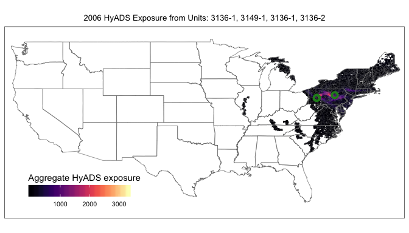

```r
zip_exp_ann_plot <- disperseR::plot_impact_weighted(data.linked=zip_exp_ann,
  data.units = unitsrun,
  zcta.dataset = zcta_dataset,
  time.agg = 'year',
  metric = 'hyads',
  legend.title = 'Aggregate HyADS exposure',
  graph.dir = graph_dir)

zip_exp_ann_plot
```

Let’s now see how to plot a monthly exposure.

Results are saved to the `exp_dir` and returned, but `return.monthly.data` must be set to true to return data when `time.agg = 'month'` (the default was set to save working memory space).

```r
zip_exp_mon <- disperseR::calculate_zip_exposure(rda_file = file.path(rdata_dir, "hyads_unwgted.RData"),
  units.mo = PP.units.monthly1995_2017,
  year.E = 2005,
  year.D = 2005,
  pollutant = 'SO2.tons',
  source.agg = 'total',
  time.agg = 'month',
  exp_dir = exp_dir,
  return.monthly.data = T)
```

[output not shown]

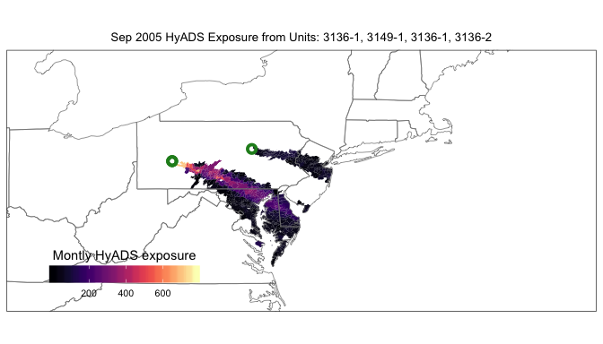

```r
zip_exp_mon_plot <- disperseR::plot_impact_weighted(data.linked = zip_exp_mon,
  data.units = unitsrun,
  zcta.dataset = zcta_dataset,
  time.agg = 'month',
  map.month = "20059",
  metric = 'hyads',
  legend.title = 'Montly HyADS exposure',
  x.lim = c(-66, -84), # specify coordinates here
  y.lim = c(36, 44),
  graph.dir = graph_dir)

zip_exp_mon_plot
```

### Plot unit-specific impacts over time

```r
zip_exp_unit_mon2005 <- disperseR::calculate_zip_exposure(rda_file = file.path(rdata_dir, "hyads_unwgted.RData"),
                                     units.mo = PP.units.monthly1995_2017,
                                     year.E = 2005,
                                     year.D = 2005,
                                     pollutant = 'SO2.tons',
                                     source.agg = 'unit', # note!
                                     time.agg = 'month',
                                     exp_dir = exp_dir,
                                     return.monthly.data = T)
```

[output not shown]

```r
zip_exp_unit_mon2006 <- disperseR::calculate_zip_exposure(rda_file = file.path(rdata_dir, "hyads_unwgted.RData"),
                                     units.mo = PP.units.monthly1995_2017,
                                     year.E = 2006,
                                     year.D = 2006,
                                     pollutant = 'SO2.tons',
                                     source.agg = 'unit', # note!
                                     time.agg = 'month',
                                     exp_dir = exp_dir,
                                     return.monthly.data = T)
```

[output not shown]

```r
zip_exp_unit_mon <- rbind(zip_exp_unit_mon2005, zip_exp_unit_mon2006)
```

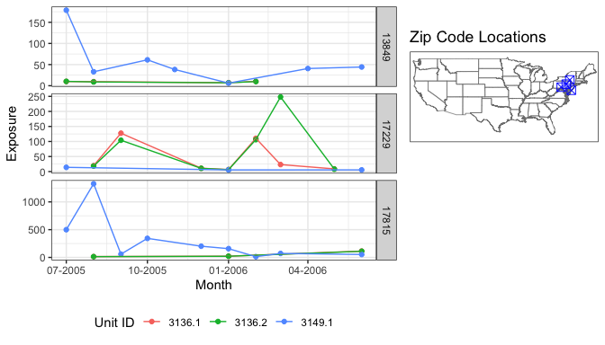

```r
zipcodes <- c(17815, 08210, 13849, 17229)

zip_exp_unit <- disperseR::plot_impact_unit(data.linked = zip_exp_unit_mon,
  zip.codes = zipcodes,
  graph.dir = graph_dir)
```

### Rank facilities.

In the examples provided above, we selected coal units a priori to analyze. However, a benefit of HyADS over more complex models is the ability to easily rank-order emissions sources to identify the sources that contribute the most to exposure in a given area.

The following code snippet applies the `calc_zip_exposure()` function to calculate annual impacts by unit (here, only the two units selected above), then rank-orders their population-weighted exposures on Pennsylvania using the `rankfacs_by_popwgt_location()` function.

```r
zip_exp_ann_unit <- disperseR::calculate_zip_exposure(year.E = 2005,
                                      year.D = 2005,
                                      pollutant = 'SO2.tons',
                                      rda_file = file.path( rdata_dir,
                                                            "hyads_unwgted.RData"),
                                      exp_dir = exp_dir,
                                      units.mo = PP.units.monthly1995_2017,
                                      source.agg = 'unit',
                                      time.agg = 'year')
```

[output not shown]

```r
# add column year for proper merge
zip_exp_ann_unit[, year := 2005]
```

In this function, the input ZIP-code linkage dataset is defined by `zip_exp_ann_unit`; the `rank.by` argument defines the variables in `zip_exp_ann_unit` to rank by—it is possible to define multiple values (e.g., rank.by = c( ‘hyads’, ‘SOx’)) to rank by multiple ranking variables if they are available; finally, `state.value`, `city.value`, and `zip.value` can be defined to limit the area of influence (here, we only rank these units’ influences on Pennsylvania with state.value = ‘PA’).

```r
unitRanks2005 <- rankfacs_by_popwgt_location(data.linked = zip_exp_ann_unit,
  crosswalk. = crosswalk,
  rank.by = c('hyads'),
  state.value = 'PA',
  year = 2005)

unitRanks2005
```

[output not shown]

### Plot ranked facilities.

`plotUnitsRanked()` works very similary to other plotting function in `disperseR`. Choose the dataset of ranked facilities as well as year.

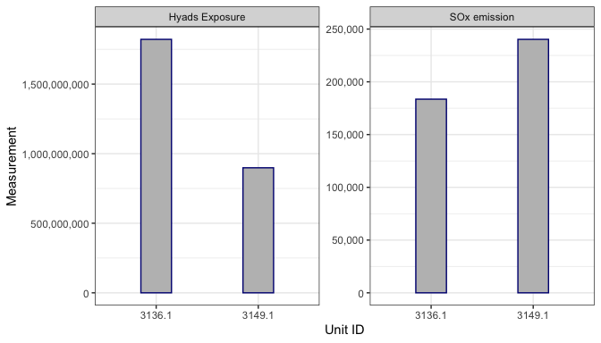

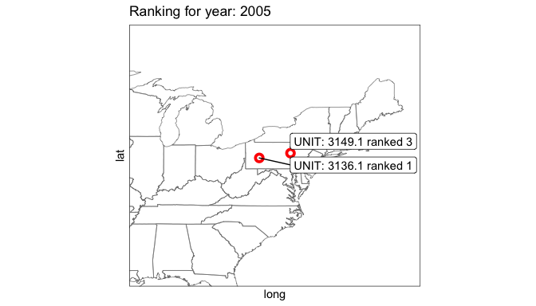

```r
plotUnitsRanked <- plot_units_ranked(data.units = unitsrun,
  data.ranked=unitRanks2005,
  year=2005,
  graph.dir = graph_dir)

plotUnitsRanked
```